# [Заметки по R](http://bdemeshev.github.io/r_cycle/): ARMA модели

02.06.2016

Загружаем нужные пакеты:

```r
library("knitr") # создание отчётов
opts_chunk$set(fig.align = 'center') # выравнивание картинок по центру

library("ggplot2") # графики
library("forecast") # прогнозирование временных рядов: ARMA и ETS модели
library("xts") # операции с временными рядами
library("dplyr") # манипуляции с данными
theme_set(theme_bw()) # чёрно-белая тема оформления графиков
```

Рассмотрим ARMA(1,1) модель

$$y_t = 0.7y_{t-1} + \varepsilon_t + 0.5\varepsilon_{t-1}$$

Рассчитаем теоретические значения ACF и PACF

```r
acf <- ARMAacf(ar = 0.7, ma = 0.5, lag.max = 10)
pacf <- ARMAacf(ar = 0.7, ma = 0.5, lag.max = 10, pacf = TRUE)
```

Покажем ACF и PACF в общей табличке. По какой-то необъяснимой логике при расчёте теоретических ACF R начинает с нулевого лага, а при расчёте PACF - с первого. Именно поэтому мы пишем `tail(acf, -1)`, это избавит нас от ACF для нулевого лага, всегда равной 1.

```r
apacf <- data_frame(lag = 1:10, acf = tail(acf, -1), pacf = pacf)
apacf
```

```
## Source: local data frame [10 x 3]
##
##      lag        acf         pacf
##    (int)      (dbl)        (dbl)
## 1      1 0.83076923  0.830769231
## 2      2 0.58153846 -0.350649351
## 3      3 0.40707692  0.168750000
## 4      4 0.28495385 -0.083591331
## 5      5 0.19946769  0.041698842
## 6      6 0.13962738 -0.020837353
## 7      7 0.09773917  0.010417169
## 8      8 0.06841742 -0.005208396
## 9      9 0.04789219  0.002604175
## 10    10 0.03352454 -0.001302084
```

Одно дело - теоретические ACF/PACF другое дело - выборочные.

Зафиксируем стартовое зерно генератора случайных чисел. Затем сгенерируем интересующий нас процесс

```r
set.seed(49)
y <- arima.sim(n = 120, list(ar = 0.7, ma = 0.5))
```

Покажем график ряда и рядом оценённые ACF/PACF

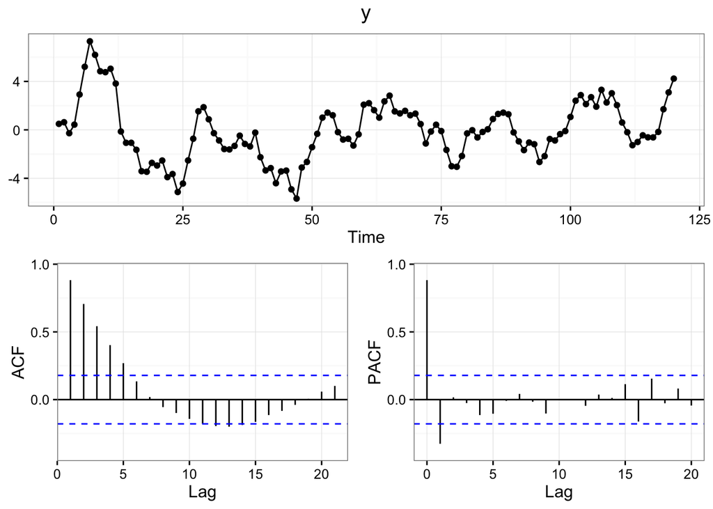

```r
ggtsdisplay(y)
```

Оценим несколько конкурирующих моделей:

Оцениваем ARMA(1,1) или ARIMA(1, 0, 1)

```r
arma11 <- Arima(y, order = c(1, 0, 1))
summary(arma11)
```

```
## Series: y
## ARIMA(1,0,1) with non-zero mean
##
## Coefficients:
##          ar1     ma1  intercept
##       0.8361  0.3882     0.1182
## s.e.  0.0537  0.0839     0.7470
##
## sigma^2 estimated as 1.034:  log likelihood=-171.73
## AIC=351.46   AICc=351.81   BIC=362.61
##
## Training set error measures:
##                        ME     RMSE       MAE      MPE     MAPE      MASE
## Training set -0.002169651 1.004134 0.7857084 38.42599 111.8123 0.8956911
##                    ACF1
## Training set 0.04530066
```

То есть оценённое ARMA(1,1) уравнение имеет вид:
$$\begin{cases}
z_t = y_t - 0.12 \\
z_t = 0.84\cdot z_{t-1} + \varepsilon_t + 0.39\varepsilon_{t-1}
\end{cases}$$

Оценим AR(2) или ARMA(2, 0) или ARIMA(2, 0, 0)

```r
ar2 <- Arima(y, order = c(2, 0, 0))
summary(ar2)
```

```
## Series: y
## ARIMA(2,0,0) with non-zero mean
##
## Coefficients:
##          ar1      ar2  intercept
##       1.2416  -0.3830     0.0619
## s.e.  0.0842   0.0847     0.6287
##
## sigma^2 estimated as 1.02:  log likelihood=-170.91
## AIC=349.81   AICc=350.16   BIC=360.96
##
## Training set error measures:
##                        ME     RMSE       MAE      MPE     MAPE      MASE
## Training set -0.002325698 0.997134 0.7879019 41.46666 117.4694 0.8981917
##                    ACF1
## Training set 0.01947124
```

То есть оценённое AR(2) уравнение имеет вид:
$$\begin{cases}
z_t = y_t - 0.06 \\
z_t = 1.24\cdot z_{t-1} - 0.38\cdot z_{t-2} + \varepsilon_t
\end{cases}$$

Отберём наилучшую модель по штрафному критерию AIC:

$$AIC = -2 \cdot \ln L + 2 \cdot k,$$
где $\ln L$ - логарифм функции правдоподобия, а $k$ - число параметров модели.

Чем больше параметров, $k$, тем сложнее модель, тем выше AIC. Чем ниже функция правдоподобия, $L$, то есть, чем ниже вероятность получить имеющиеся данные при данной модели, тем выше AIC.

```r
AIC(ar2)
```

```
## [1] 349.8132
```

```r
AIC(arma11)
```

```
## [1] 351.4617
```

По критерию AIC лучше оказалась модель AR(2).

Можно также использовать BIC
$$BIC = -2 \cdot \ln L + \ln n \cdot k.$$

```r
BIC(ar2)
```

```
## [1] 360.9632
```

```r
BIC(arma11)
```

```
## [1] 362.6117
```

По критерию BIC также лучше AR(2) моделиь.

Проверим остатки выбранной модели на отсутствие автокорреляции с помощью теста Льюнга-Бокса:

$$H_0: \rho_1 = \rho_2 = \ldots = \rho_k$$

$H_a$: хотя бы одна из корреляций не равна нулю

$$LB = n (n+1) \sum_{k=1}^h \frac{\hat \rho_k^2}{n - k}$$

Если применять статистику $LB$ к исходному ряду, то при верной $H_0$ статистика имеет $\chi^2$-распределение с $h$ степенями свободы. Если к остаткам ARMA(p, q) модели, то количество степеней свободы падает до $h - (p+q)$.

Мы оценивали AR(2) модель, поэтому степени свободы падают на $p+q = 2$. Указываем значение аргумента `fitdf` равное $p+q=2$:

```r
resid_ar2 <- resid(ar2)
Box.test(resid_ar2, lag = 10, type = "Ljung-Box", fitdf = 2)
```

```
##
##  Box-Ljung test
##
## data:  resid_ar2
## X-squared = 3.6701, df = 8, p-value = 0.8856
```

У нас $H_0$ не отвергается, значит можно считать, что модель корректно описывает структуру корреляции.

Для несезонных рядов [Rob Hyndman](http://robjhyndman.com/hyndsight/ljung-box-test/) рекомендует брать `lag`, $h = 10$, для сезонных $h = 2m$, где $m$ — периодичность сезонности, т.е. $h=24$ для месячных данных.

Для ARMA(p, q) можно посмотреть визуально, где лежат корни AR и MA части:

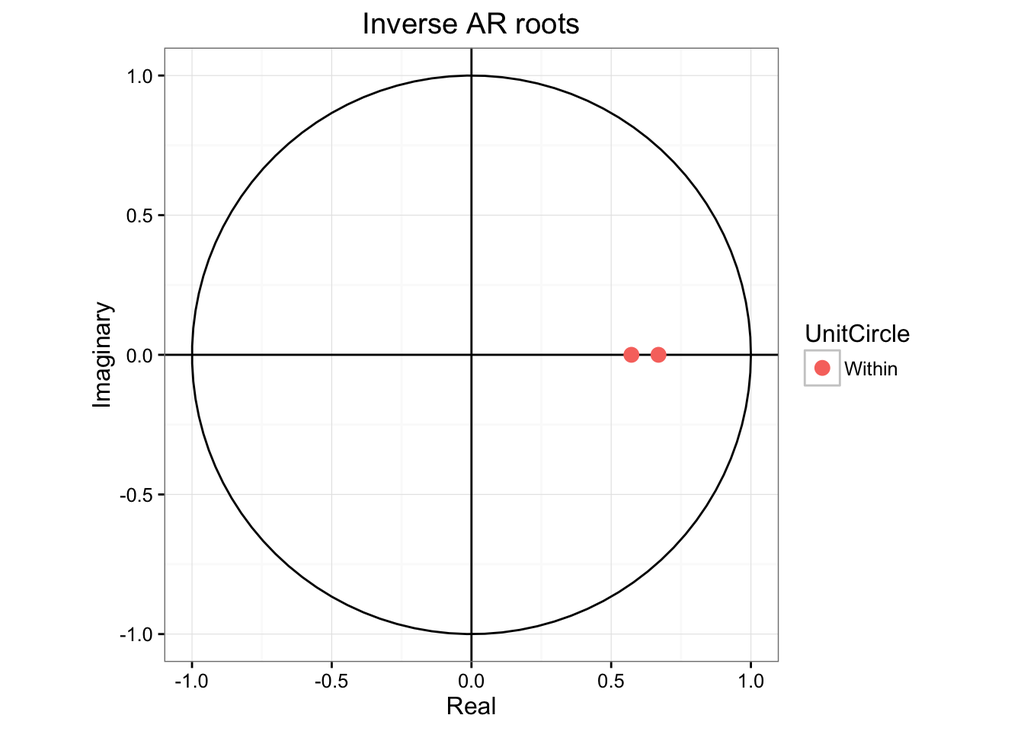

```r
autoplot(ar2)
```

По выбранной наилучшей модели можно строить прогнозы:

```r
forecast(ar2, h = 5)
```

```
##     Point Forecast      Lo 80    Hi 80      Lo 95    Hi 95
## 121       4.079150  2.7849924 5.373308  2.0999065 6.058394
## 122       3.451918  1.3887296 5.515107  0.2965434 6.607293
## 123       2.732169  0.1817341 5.282604 -1.1683845 6.632723
## 124       2.078785 -0.7597748 4.917344 -2.2624174 6.419987
## 125       1.543238 -1.4573955 4.543871 -3.0458347 6.132310
```

Или можно построить график прогнозов с предиктивными интервалами:

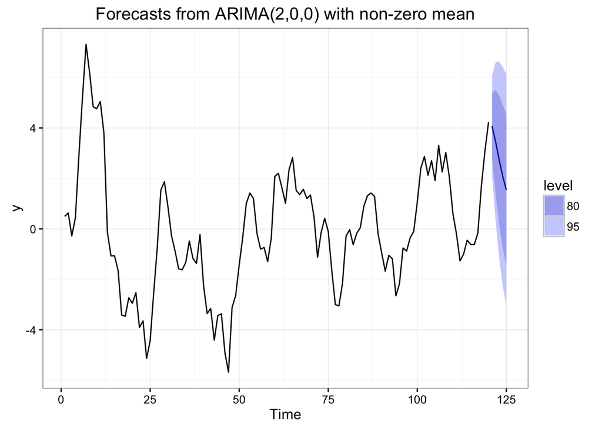

```r
future <- forecast(ar2, h = 5)
autoplot(future)
```

Но всё уже придумано до нас

[figure not shown]

Уже

И особо ленивые могут воспользоваться готовой функцией

```r
model <- auto.arima(y)
summary(model)
```

```
## Series: y
## ARIMA(1,0,1) with zero mean
##
## Coefficients:
##          ar1     ma1
##       0.8357  0.3886
## s.e.  0.0537  0.0839
##
## sigma^2 estimated as 1.026:  log likelihood=-171.74
## AIC=349.49   AICc=349.69   BIC=357.85
##
## Training set error measures:
##                      ME     RMSE       MAE      MPE     MAPE      MASE
## Training set 0.01201994 1.004247 0.7856238 37.28652 111.0717 0.8955947
##                    ACF1
## Training set 0.04543413
```

Пакет `forecast` автоматически отбирает $ARMA(1, 1)$

Из известных мне косяков: пакет `forecast` может отказываться подключаться, если окошко для графиков в Rstudio очень маленькое :)

### Чтиво:

- Rob Hyndman, [Forecasting principles and practice](https://www.otexts.org/fpp/8). Отличный учебник по временным рядам с примерами на R
- Rob Hyndman, [Automatic Time Series Forecasting](https://www.jstatsoft.org/article/view/v027i03). Подробности про функцию `auto.arima`.